# 1. Processing Data: 21LT2

Friederike Dündar

March 2020; updated 2020-04-08

# Background

There are two types of samples from previously *in vitro* sensitized T cells to be compared here:

- T cells presented with the **irrelevant** antigen, and
- T cells presented with the **tumor antigen**

Both samples contain a mixture of T cells and APC, although the ratio is skewed heavily towards T cells (approximately 10:1).

All samples were processed at the Epigenomics Core (WCM) using the Chromium Single Cell Immune Profiling Solution. This method allows to obtain both the gene expression profile and T-cell receptor repertoires from the same input sample. In short, for each input sample, a single batch of barcoded droplets was created followed by cDNA library generation for each cell. After cDNA amplification, each sample was split into two aliquots, of which one was subjected to T cell enrichment (`Chromium Human T Cell`). Both aliquots were then sequenced separately, yielding two distinct libraries from the same input samples (identified with separate I7 indices). Using the `CellRanger` package supplied by 10X Genomics, the Epigenomics Core created two files per sample:

- a count matrix of transcript counts per gene and cell, and
- a table of TRA/TRB clonotypes per cell.

The pipeline includes read alignment to the human genome and removal of barcodes with very low read counts. The annotation files that were used were `vdj_GRCh38_alts_ensembl-3.1.0-3.1.0` and `GRCh38-3.0.0`.

The Epigenomics Core ID is: `EC-SC-5166`, which will allow the retrieval of the original Cell Ranger output.

## Data processing

Our data processing encompassed additional quality checks and removal of genes and cells with aberrant transcript numbers and lack of VDJ information.

## Summary

```r
library(Klebanoff21LT2)
data(cell_filt)
data(gene_filt)
```

# Processing

## Reading in

Reading in the count matrices and VDJ resuls as provided by CellRanger.

```r
library(data.table)
library(magrittr)
library(SingleCellExperiment)
library(ggplot2); theme_set(theme_bw(base_size = 16) )
library(ggrepel)
library(patchwork)
```

```r
cell_filt <- list()
gene_filt <- list()

## CLONOTYPE INFO ===========================
samplename <- "21LT2"
data_dir <- "/scratchLocal/frd2007/2018-11_Smita_Tcells/data/21LT2/"
## stored within the tar.gz generated with CellRanger and downloaded from PubShare
clono_info_wt <- reading_in_clonotypes(paste0(data_dir,"WT_VDJ/")) # 21LT2_H-VDJ.tar.gz
clono_info_mut <- reading_in_clonotypes(paste0(data_dir,"MUT_VDJ/")) # 21LT2_R-VDJ.tar.gz

## READ COUNTS ==============================
# list.files(dir.name) # "barcodes.tsv" "genes.tsv"    "matrix.mtx"
wt <- paste0(data_dir, "WT_GEX/outs/filtered_feature_bc_matrix")
mut <- paste0(data_dir, "MUT_GEX/outs/filtered_feature_bc_matrix")

sce.wt <- DropletUtils::read10xCounts(wt,
  sample.names = paste("WT", samplename, sep = "."),
  version = "auto")
sce.wt$cell <- paste(sce.wt$Sample, 1:ncol(sce.wt), sep = "_")
colnames(sce.wt) <- sce.wt$cell

sce.mut <- DropletUtils::read10xCounts(mut,
  sample.names = paste("MUT", samplename, sep = "."),
  version = "auto")
sce.mut$cell <-  paste(sce.mut$Sample, 1:ncol(sce.mut), sep = "_")
colnames(sce.mut) <- sce.mut$cell

## prepare cell info
ci.wt <- prep_cell_info(sce.wt, clono_info_wt)
ci.mut <- prep_cell_info(sce.mut, clono_info_mut)

## COMBINE ------------------------------------
cts <- cbind(counts(sce.mut), counts(sce.wt)) ## keep order!
cell_filt$ori <- ncol(cts)
gene_filt$ori <- nrow(cts)

## combine colData
cd <- rbind(ci.mut, ci.wt)
cd <- cd[colnames(cts),]

## rowData prep
gene_info <- rowData(sce.mut)[, c(1:2)]
names(gene_info) <- c("ensembl_id","gene_symbol")

## make SCE object --------------------------------------------
sce <- SingleCellExperiment(assays = list(counts = cts),
  colData = cd,
  rowData = gene_info[rownames(cts),])

## remove genes with only zero counts----------------------------
keep <- rowSums(counts(sce)) > 0
sce <- sce[keep,]
dim(sce)
#[1]] 21453  7533
# [1] 21992 11173 re-process, 2020
gene_filt$first_all_zeros <- nrow(sce)

## ADD CHROMOSOME INFO & CELL QC METRICS -------------------
sce <- get_mito(sce)
is.mito <- rowData(sce)$chr == "chrMT"
sce <- add_cell_qc(sce, is.mito)
##! saveRDS(sce, file = "sce_21LT2_unfiltered.rds")
```

## Remove low-quality cells

```r
png("qc_per_cell.png", height = 600, width = 700)
p1 <- scater::plotColData(sce,
  y = "Sample", x = "log10_total_features",
  colour_by = "Sample") +
  theme(legend.position = "bottom") +
  scale_fill_manual(values = c("dodgerblue1","limegreen"))

p2 <- scater::plotColData(sce,
  y = "Sample", x = "subsets_mitochondrial_percent",
  colour_by = "Sample") +
  theme(legend.position = "none")+
  scale_fill_manual(values = c("dodgerblue1","limegreen"))

p3 <- scater::plotColData(sce,
  y = "log10_total_features", x = "subsets_mitochondrial_percent",
  colour_by = "Sample",  other_fields = "Sample") +
  facet_grid(~Sample) +
  theme(legend.position = "none")+
  scale_fill_manual(values = c("dodgerblue1","limegreen"))

(p1 | p2 ) / p3
dev.off()
```

```r
options(stringsAsFactors = FALSE)
sce.filt <- sce
rm(sce); gc()
## Mito content ---------------------------------------------------------
high.mito <- scater::isOutlier(sce.filt$subsets_mitochondrial_percent, nmads = 5, type = "higher")
sce.filt[, !high.mito]$subsets_mitochondrial_percent %>% max
# [1] 14.68138
# [1] 19.03831 ## re-process, 2020

### manually defined mitochondrial threshold: 14%
high.mito <- sce.filt$subsets_mitochondrial_percent >= 14
sce.filt <- sce.filt[, !high.mito]
cell_filt$mito <- ncol(sce.filt)

## Number of genes per cell--------------------------------------------
outlier.genes <- scater::isOutlier(sce.filt$detected, nmads = 3, type = "both")
sce.filt[, !outlier.genes]$log10_total_features  %>% summary
#Min. 1st Qu.  Median    Mean 3rd Qu.    Max.
# 3.011   3.420   3.498   3.526   3.630   3.809
## re-process, 2020:
#   Min. 1st Qu.  Median    Mean 3rd Qu.    Max.
#   2.220   3.357   3.449   3.446   3.587   3.794

sce.filt <- sce.filt[, !outlier.genes]
# [1] 21992  8984 ## re-process, 2020
cell_filt$n_features <- ncol(sce.filt)

## immediately remove no-coverage-genes --------------------------------------
keep <- rowSums(counts(sce.filt)) > 0
sce.filt <- sce.filt[keep,]

dim(sce.filt)
#[1]  21430  8984 # re-process, 2020
gene_filt$low_qual_cells <- nrow(sce.filt)

## CELL CYCLE STATUS ---------------------------------------------------------
cc.noNormAllCells <- get_cc_info(sce.filt, print_results = TRUE)

# G1  G2M    S
#3258  223  674
#################
#      mut   wt
# G1  2433 3582
# G2M  156  290
# S    404  460
###############
#     MUT   WT
#G1  1256 2002
#G2M   75  148
#S    302  372
colData(sce.filt)$cc_phase <- cc.noNormAllCells$phases
colData(sce.filt)$G1score <- cc.noNormAllCells$score$G1
colData(sce.filt)$G2Mscore <- cc.noNormAllCells$score$G2M

## make more sensible rownames ---------------------------
rownames(sce.filt) <- scater::uniquifyFeatureNames(
  rowData(sce.filt)$ensembl_id,
  rowData(sce.filt)$gene_symbol)

!##saveRDS(sce.filt, file = "sce_21LT2_filtered.rds")
```

Counts & genes per cell before filtering:

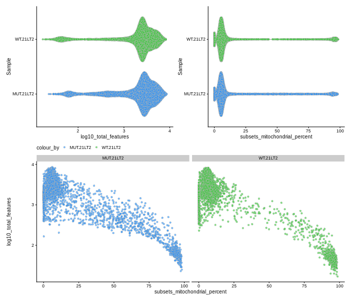

## QC & Filtering of Genes

```r
## calculate qc metrics per gene across all the cells of the same sample
gnqc.list <- do_gene_qc(sce.filt, return_df = TRUE)
gn.qc <- gnqc.list$gene_qc

png("qc_genes.png", width=1000, height = 750)
p1 <- ggplot(data = data.frame(gn.qc), aes(x = subsets_WT.21LT2_mean,
  y = subsets_WT.21LT2_detected)) +
  geom_point(shape=1, size=.5) +
  ggtitle("WT 21LT2") +
  scale_x_log10() + scale_y_log10() +
  ylab("% cells with non-zero expression") + xlab("mean counts")
p1 <- p1 +
  geom_point(data = subset(data.frame(gn.qc), Gene %in% gnqc.list$hk_genes),
    color = "red",shape = 22, size = 4)

p2 <- ggplot(data = data.frame(gn.qc), aes(x = subsets_MUT.21LT2_mean,
  y = subsets_MUT.21LT2_detected)) + geom_point(shape=1, size=.5) +
  ggtitle("MUT 21LT2") +
  scale_x_log10() + scale_y_log10() +
  ylab("% cells with non-zero expression") + xlab("mean counts")
p2 <- p2 +
  geom_point(data = subset(data.frame(gn.qc), Gene %in% gnqc.list$hk_genes),
    color = "red",shape = 22, size = 4)

p3 <- ggplot(data = data.frame(gn.qc),
  aes(x = subsets_MUT.21LT2_detected, y = subsets_WT.21LT2_detected)) +
  geom_point(shape=1, size=.5, alpha =.5) +
  scale_x_log10() + scale_y_log10()
p3 <- p3 +
  geom_point(data = subset(data.frame(gn.qc), Gene %in% gnqc.list$hk_genes),
    color = "red",shape = 22, size = 4)
(p1 | p2) / p3
dev.off()

png("qc_highestExpressedGenes.png", width= 550, height = 500)
scater::plotHighestExprs(sce.filt)
dev.off()
```

Dropout rate assessment:

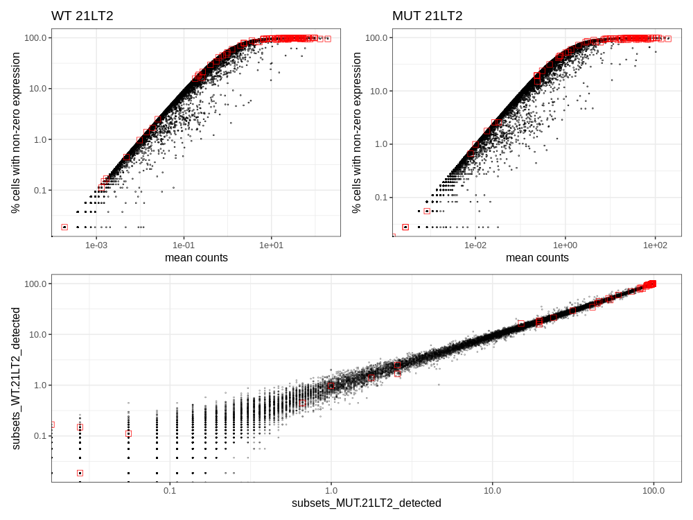

Highest expressed genes:

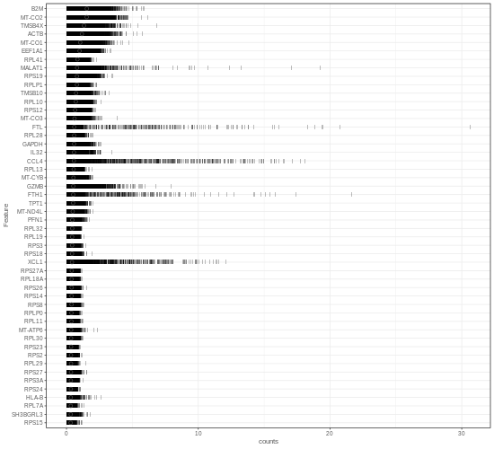

```r
keep_genes <-  do_gene_qc(sce.filt, min.cells = 5, return_df = FALSE)
sce.filt <- sce.filt[gnqc.list$keep_genes,]

dim(sce.filt)
# > dim(sce.filt)
# [1] 18776  8984 # re-process, 2020
gene_filt$low_qual_genes <- nrow(sce.filt)

!##saveRDS(sce.filt, file = "sce_21LT2_filtered.rds")
```

## Normalization and Dimensionality Reductions

Following filtering, we’re going to normalize, adjusting for batch effect (=Sample) and performing dimensionality reduction.

```r
library(scran)
library(batchelor)
library(scater)

## size factor --------------------------------------
#message("calculating the size factors")
qckclst <- quickCluster(sce.filt, method = "igraph",
  min.mean = 0.1)
sce.filt <- computeSumFactors(sce.filt, min.mean=0.1, cluster = qckclst)
sce.filt <- scater::logNormCounts(sce.filt)
##!saveRDS(sce.filt, file = "sce_21LT2_filtered.rds")

## variance modelling -------------------------------
dec.filt <- modelGeneVar(sce.filt, block=sce.filt$Sample)
chosen.hvgs <- dec.filt$bio > 0
table(chosen.hvgs)
#chosen.hvgs
#FALSE  TRUE
#10025  8751

#--- merging ---#
set.seed(01001001)
sce.merged <- correctExperiments(sce.filt,
    batch=sce.filt$Sample,
    subset.row=chosen.hvgs)

sce.merged
#class: SingleCellExperiment
#dim: 8565 9015
#metadata(1): merge.info
#assays(3): reconstructed counts logcounts
#rownames(8565): MIR1302-2HG AL627309.1 ... AC004556.1 AC240274.1
#rowData names(4): ensembl_id gene_symbol chr rotation
#colnames(9015): MUT.21LT22 MUT.21LT23 ... WT.21LT26363 WT.21LT26364
#colData names(18): batch Barcode ... G1score G2Mscore
#reducedDimNames(1): corrected
#spikeNames(0):
#altExpNames(0):
##! saveRDS(sce.merged, file = "sce_batchCorrected.rds")
```

## Remove cells without clonotype information

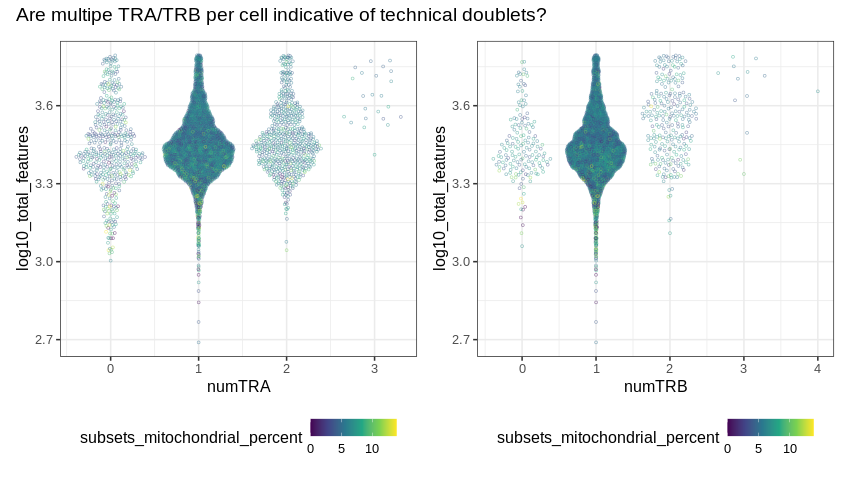

```r
## REMOVING CELLS WITHOUT CLONOTYPE----------------------------
sce.filt <- sce.filt[,which(!is.na(sce.filt$cdr3s_aa))]
dim(sce.filt)
# [1] 18776  5172
cell_filt$clonotype <- ncol(sce.filt)

## frequencies of chains, i.e. counting number of TRA/TRB entries within cdr3s_aa column
sce.filt <- add_chain_counts(sce.filt)
## frequency of clonotypes, i.e. counting individual cdr3s_aa entries
sce.filt$freq_per_Sample <- add_frequencies(sce.filt, mode = "per.sample")
sce.filt$freq_across_all <- add_frequencies(sce.filt, mode = "all")

## REMOVING PUTATIVE DOUBLETS --------------------------------
png("relationship_TRB_features.png", width = 850)
cd <- colData(sce.filt)
p1 <- ggplot(as.data.frame(cd), aes(x = numTRA,
  y = log10_total_features, color = subsets_mitochondrial_percent)) +
  ggbeeswarm::geom_quasirandom(size = 1, alpha = .5, shape = 1) +
  theme(legend.position = "bottom") +
  scale_colour_viridis_c()

p2 <- ggplot(as.data.frame(cd), aes(x = numTRB,
  y = log10_total_features, color = subsets_mitochondrial_percent)) +
  ggbeeswarm::geom_quasirandom(size = 1, alpha = .5, shape = 1) +
 # ggtitle(" 'Cells' with more than 1 TRB tend to have increased numbers of counts") +
  theme(legend.position = "bottom") +
  scale_colour_viridis_c()

pw <- p1 + p2
pw + plot_annotation(
  title = 'Are multipe TRA/TRB per cell indicative of technical doublets?'
  #subtitle = 'These 3 plots will reveal yet-untold secrets about our beloved data-set',
  #caption = 'Disclaimer: None of these plots are insightful'
)
dev.off()

## after looking at these plots, I'm fairly certain that removing cells with more
## than 2 TRB is benefitial to avoid doublets
sce.filt <- sce.filt[, sce.filt$numTRB < 2 & sce.filt$numTRA < 2]
## remove all-newly-only-zero-genes
keep <- rowSums(as.matrix(counts(sce.filt))) > 0
sce.filt <- sce.filt[keep, ]
cell_filt$clonotype_doubs <- ncol(sce.filt)
gene_filt$clonotype_doubs <- nrow(sce.filt)

dim(sce.filt)
#[1] [1] 18382  4392

keep <- do_gene_qc(sce.filt, min.cells = 5, return_df = FALSE)
gene_filt$clonotype_doubs_min5 <- nrow(sce.filt)
```

## Clustering

```r
kp <- rownames(sce.merged) %in% rownames(sce.filt)
sce.merged <- sce.merged[kp, colnames(sce.filt)]
##  clustering using the batch-corrected values ---------------
g <- buildSNNGraph(sce.merged, use.dimred="corrected")
clusters <- igraph::cluster_louvain(g)
sce.merged$cluster <- factor(clusters$membership)

#--- dimensionality-reduction ---#
sce.merged <- runTSNE(sce.merged, dimred="corrected", external_neighbors=TRUE)
sce.merged <- runUMAP(sce.merged, dimred="corrected", external_neighbors=TRUE)

png("umap_samples.png")
p1 <- plotReducedDim(sce.merged, dimred="UMAP", colour_by="Sample") +
    scale_fill_manual(values = c("dodgerblue1","limegreen"))
p2 <- plotReducedDim(sce.merged, dimred="UMAP", colour_by="cluster",
   other_fields = "Sample") +
  facet_grid(~Sample)
p1 / p2
dev.off()

##!saveRDS(sce.merged, file = "sce_batchCorrected.rds")

reducedDims(sce.filt) <- reducedDims(sce.merged)
sce.filt$cluster <- sce.merged$cluster

##! saveRDS(sce.filt, file = "sce_21LT2_clonotypefiltered.rds")
##! saveRDS(sce.merged, file = "sce_21LT2_batchCorrected_clonotypefiltered.rds")
```

# Results

```r
sce.filt <- load_21LT2filt()
```

```
#> Cached data here: /Users/frd2007/Library/Caches/BiocFileCache/75ea431ce34b_772dr9kbhj69jhn095tptlrbm7fj6948.rds
#> Cached data here: /Users/frd2007/Library/Caches/BiocFileCache/75ea1d8e7359_s8cvvxm9ewzl2nd0bex5teqg9tp4yjtj.rds
#> Cached data here: /Users/frd2007/Library/Caches/BiocFileCache/75ea7336e737_55vmjk69lgt258up3cg6n173jgzxkdkx.rds
#> Cached data here: /Users/frd2007/Library/Caches/BiocFileCache/75ea198606f9_qadlxweirl445ywp1ho9ta4unzo0uuz6.rds
#> Cached data here: /Users/frd2007/Library/Caches/BiocFileCache/75ea2e33d286_5wxagdv7b6i8okcu4msednx9dtu9lpre.rds
#> Cached data here: /Users/frd2007/Library/Caches/BiocFileCache/75ea4c42731c_399wym8ybnowpjzew5mg37vez6t5i1v0.rds
```

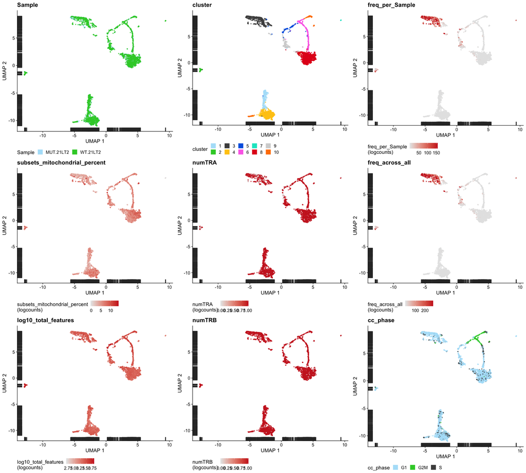

## Monocytes

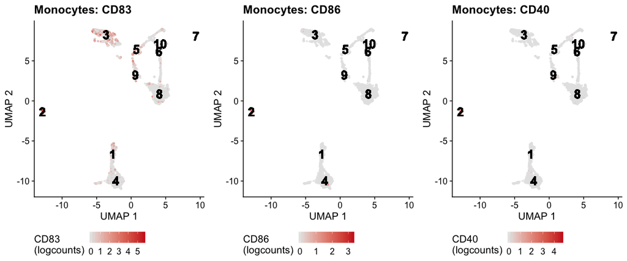

## NK cells, DCs, B cells

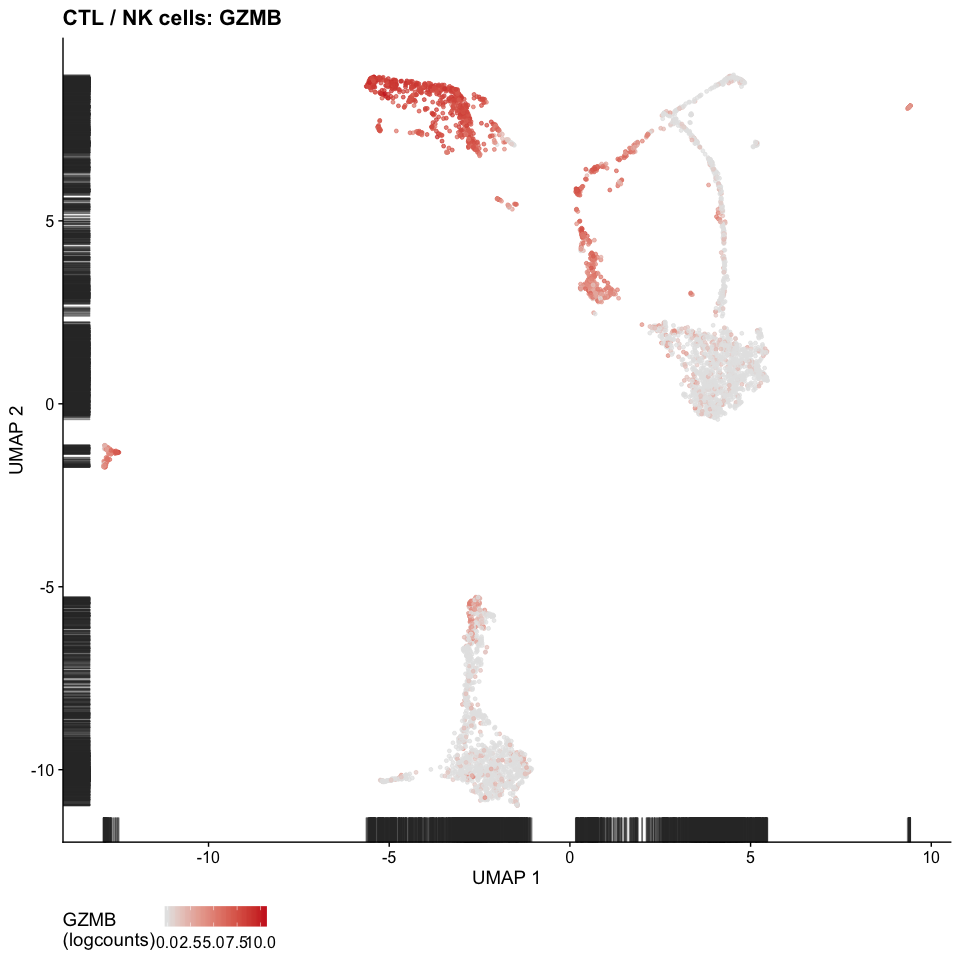

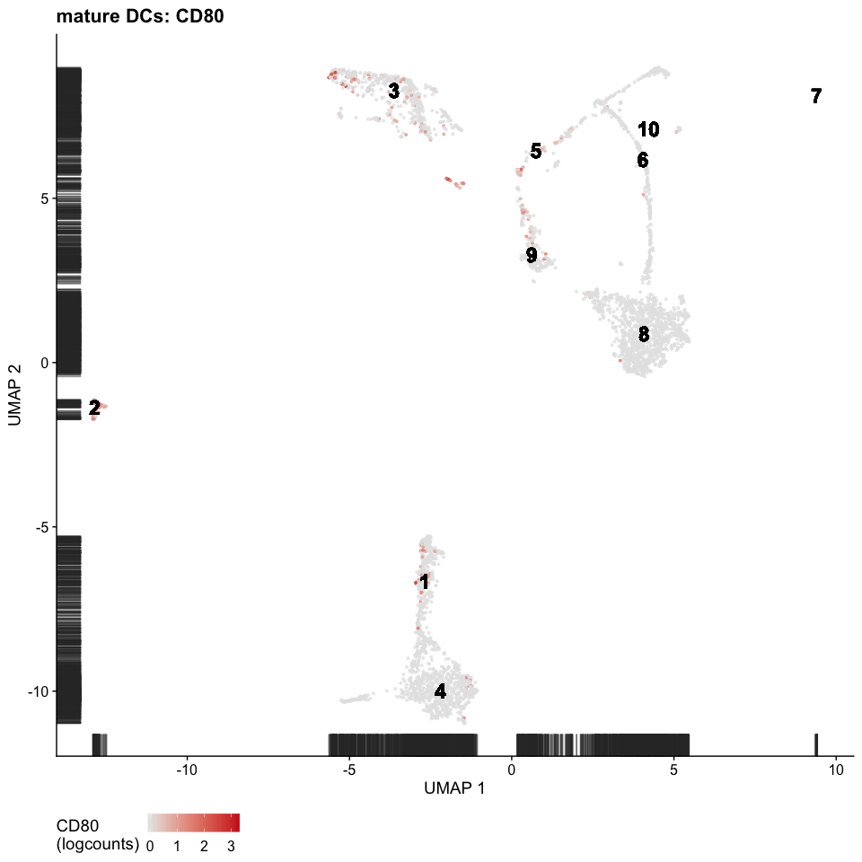

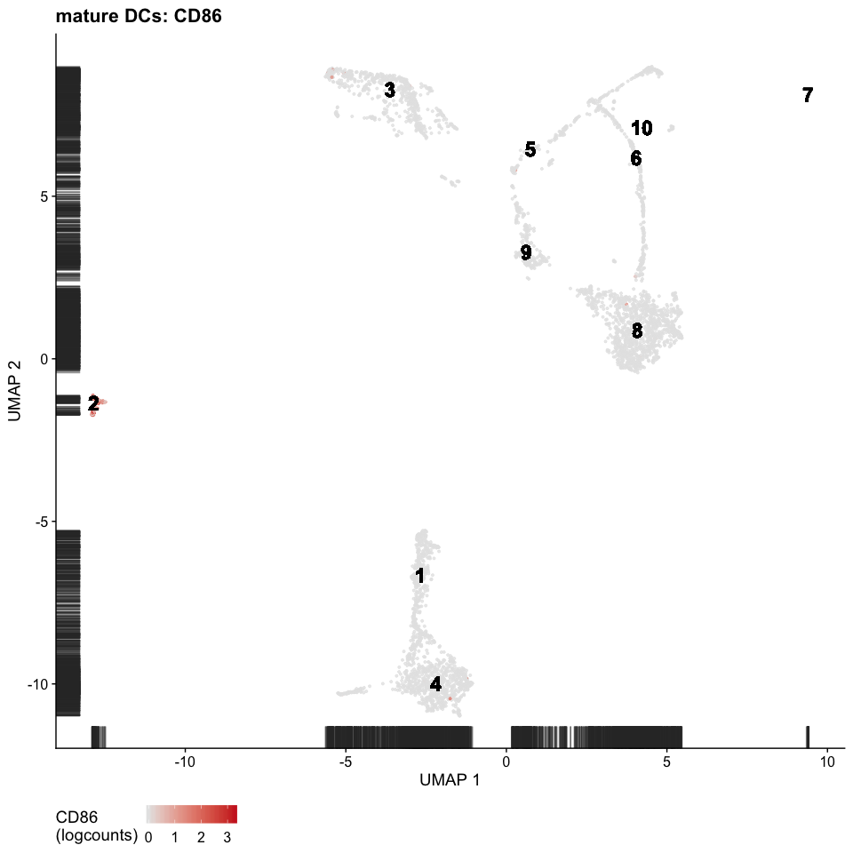

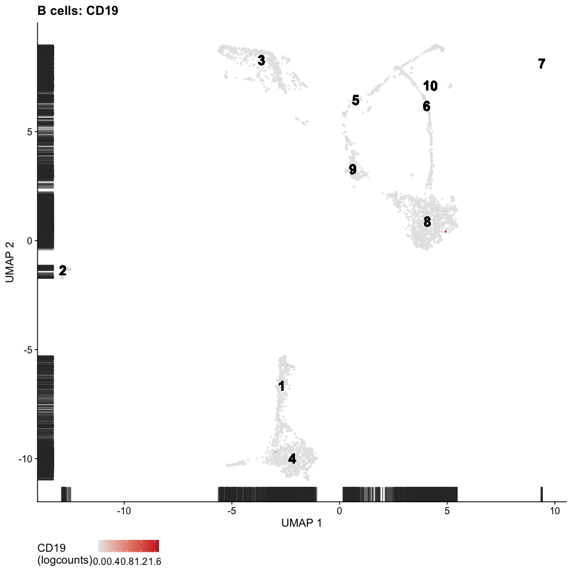

## T cells

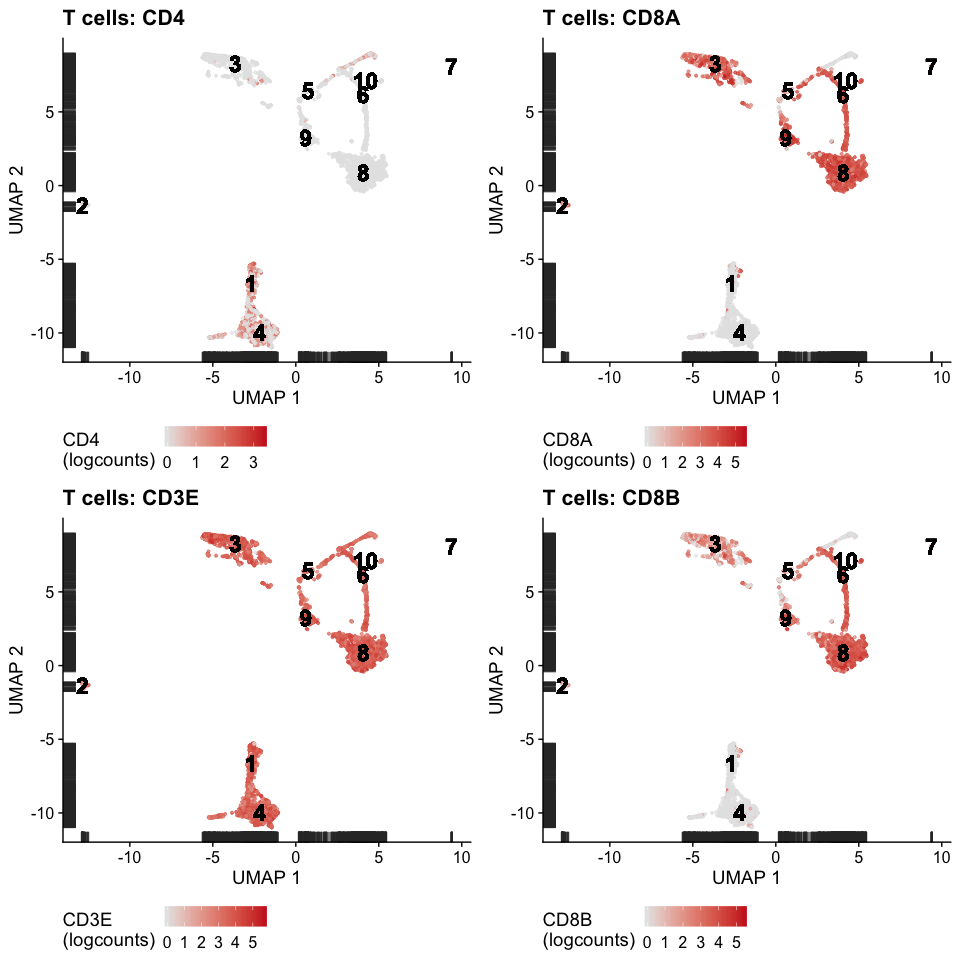

## Markers of activation

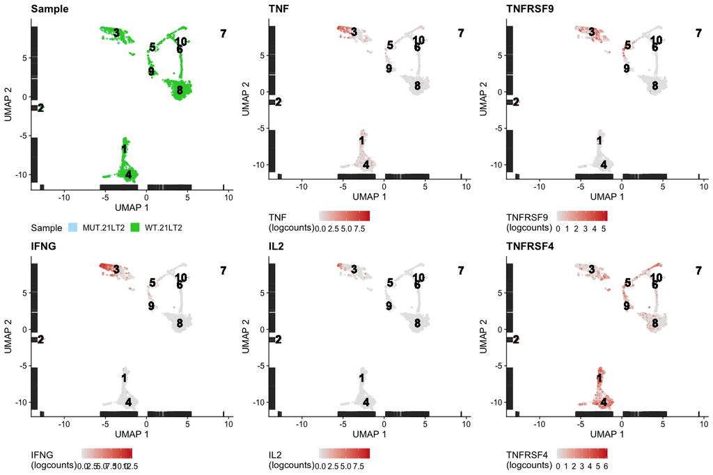

| Cluster | Identity |
| --- | --- |
| 1 | CD4 |
| 2 | Monocytes |
| 3 | **activated CD8** |
| 4 | CD4 |
| 5 | unclear, tiny |
| 6 | CD8 (in G2M) |
| 7 | unclear, tiny |
| 8 | CD8 |
| 9 | CD8 |
| 10 | CD8 |

# Identify shared clonotypes

= clonotypes that are present in both conditions, i.e. MUT and WT.

Get a data.table with unique clonotypes per sample:

```r
## clonotype frequencies
clono_freq <- colData(sce.filt)[, c("Sample" ,"cdr3s_aa")] %>%
  as.data.frame %>% data.table(., keep.rownames = TRUE) %>%
  .[!is.na(cdr3s_aa), .N, c("cdr3s_aa","Sample")]
setorder(clono_freq, N)
```

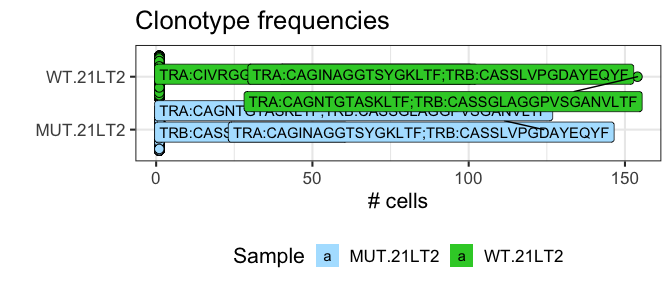

```r
ggplot(clono_freq, aes(x = Sample, y = N, key = cdr3s_aa, fill = Sample)) +
  ggbeeswarm::geom_quasirandom(size = 3, shape = 21) +
  ggrepel::geom_label_repel(data = clono_freq[N>30], aes(label = cdr3s_aa), box.padding = 1) +
  scale_fill_manual(values = c("lightskyblue1","limegreen")) +
  coord_flip() + ylab("# cells") + xlab("") +
  ggtitle("Clonotype frequencies") +
  theme(legend.position = "bottom")
```

Identify clonotypes that are present in both sample types:

```r
ct <- dcast(clono_freq, cdr3s_aa ~ Sample, value.var = "N") %>% .[!is.na(MUT.21LT2) & !is.na(WT.21LT2)]
```

There are 71 clonotypes that are found in both MUT and WT samples.

```r
## formatting the TRA/TRB notations
## will only work if there's just one TRA
ct[, TRA := gsub(";*TRB:[A-Z]+", "", cdr3s_aa)]
ct[, TRA := ifelse(TRA == "", NA, TRA)]
ct[, TRB := gsub(".*(TRB:[A-Z]+)", "\\1", cdr3s_aa)]
ct[, TRB := ifelse(grepl("^TRA", TRB), NA, TRB)] # if only TRB was present, I need to fill in the NA

setorder(ct, -MUT.21LT2, -WT.21LT2 )
ct[]
```

```
#>                                       cdr3s_aa MUT.21LT2 WT.21LT2
#>  1:  TRA:CAGNTGTASKLTF;TRB:CASSGLAGGPVSGANVLTF       124      154
#>  2:   TRA:CAGINAGGTSYGKLTF;TRB:CASSLVPGDAYEQYF        99      116
#>  3:                        TRB:CASSLVPGDAYEQYF        61      101
#>  4:        TRA:CIVRGGKLIF;TRB:CASSLALGYLNTEAFF        25       35
#>  5:         TRA:CAMRANDYKLSF;TRB:CASSLRADSEQYF        17       14
#>  6:       TRA:CAVRPRNDYKLSF;TRB:CASAVWGVADIQYF        15       18
#>  7:        TRA:CGAVGNTGKLIF;TRB:CAISGGRSSYEQYF        14       18
#>  8:                    TRB:CASSGLAGGPVSGANVLTF        12       14
#>  9:    TRA:CATDASRGSQGNLIF;TRB:CASTPLPTKARGYTF         8       12
#> 10:          TRA:CAASINQFYF;TRB:CASSYGGYQETQYF         8        7
#> 11:        TRA:CALNAGGTSYGKLTF;TRB:CASSLRTEAFF         7       11
#> 12:      TRA:CAGQLSLDGQKLLF;TRB:CASSLGTSYNEQFF         6       26
#> 13:           TRA:CAVNFGGFKTIF;TRB:CSANLAGEQYF         4        8
#> 14:     TRA:CAFREGAQKLVF;TRB:CAISDRGDRRPTGELFF         4        6
```

[output cut: 131 more lines]

```r
shared_clonotypes <- copy(ct)
```

```r
usethis::use_data(shared_clonotypes)
```

## Dimensionality reduction on the shared clonotypes only

UMAP of **shared clonotypes**

```r
sce.shared <- sce.filt[, sce.filt$cdr3s_aa %in% ct$cdr3s_aa]
```

There are 1139 cells in the SCE object with clonotypes that are present in both samples.

```r
set.seed(123)
sce.shared <- scater::runUMAP(sce.shared,
  exprs_values = "logcounts",
  dimred = "corrected")
```

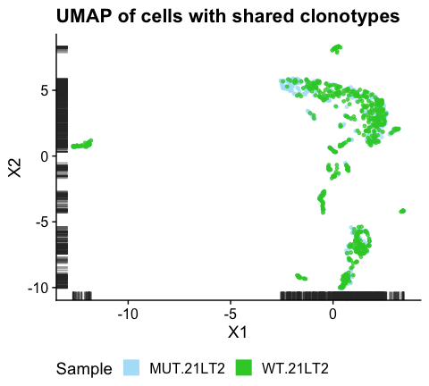

```r
## add clonotype ID and consolidated info to the SCE object
data("clonotype_ids", package = "Klebanoff21LT2") ## loading unique identifiers of the shared clonotypes

cd.ct <-  data.table(as.data.frame(colData(sce.shared)), keep.rownames = TRUE)
cd.ct <- clonotype_ids[cd.ct, on = "cdr3s_aa"]
cd.ct <-  DataFrame(cd.ct[, -"rn"], row.names = cd.ct$rn)
colData(sce.shared) <- cd.ct[colnames(sce.shared),]

cd.all <- data.table(as.data.frame(colData(sce.filt)), keep.rownames = TRUE)
cd.all <- clonotype_ids[cd.all, on = "cdr3s_aa"]
cd.all <-  DataFrame(cd.all[, -"rn"], row.names = cd.all$rn)
colData(sce.filt) <- cd.all[colnames(sce.filt),]
```

When coloring the cells by the total number of genes detected, it becomes apparent that the distinct cluster on the left is probably composed of droplets where more than one cell was captured (= doublets).

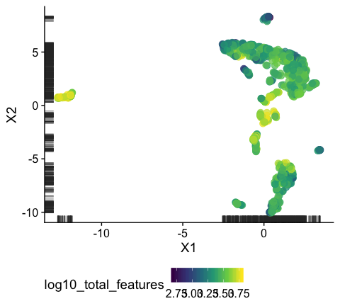

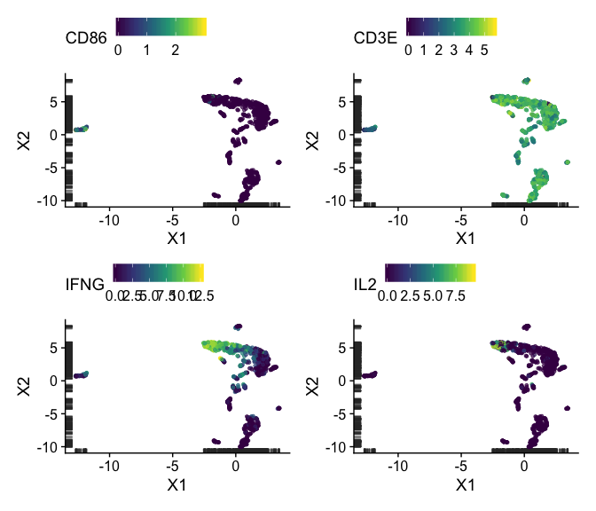

## Removal of suspected doublets

Let’s remove them using the UMAP coordinates.

```r
umap.dt <- reducedDim(sce.shared, "UMAP") %>% data.table(., keep.rownames = TRUE)
outs <- umap.dt[V1 < -10]$rn
sce.shared$umap_group <- ifelse(rownames(colData(sce.shared)) %in% outs, "doublets", "tcells")
table(sce.shared$umap_group)
```

```
#>
#> doublets   tcells
#>       55     1084
```

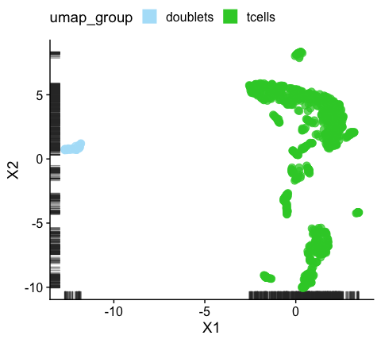

```r
## remove doublets from the SCE
sce.shared <- sce.shared[, sce.shared$umap_group != "doublets"]
set.seed(123)
sce.shared <- scater::runUMAP(sce.shared, exprs_values = "logcounts",
  dimred = "corrected")
colnames(reducedDim(sce.shared, "UMAP")) <- c("UMAP_1","UMAP_2")

##!saveRDS(sce.shared, file = "~/Documents/Projects/2018-10_Smita/data/sce_sharedClonotypes_Mar2020.RDS")
```

[figure not shown]

# Saving

```r
## for data stored in the data/ folder of the package
usethis::use_data(cell_filt)
usethis::use_data(gene_filt)
```

```r
## the indidivudal components of the sce data set will be stored on the Box because
## they are too big to be part of the package
## I therefore save them in a separate folder (sce_components_*) which I will then move to
## the Box (Folder: Klebanoff_SingleCellData). In the Box, I then navigate to the folder and retrieve the *direct* shared
## links (--> "Share file" --> "Enable shared link" --> "Settings/Properties" --> get the *direct*
## link (should end with .rds). That link is then stored in a text file, which I keep
## in the inst/extdata folder and will be used by the function to retrieve the data
## (see load_sce() in R/data_sce.R)
saveRDS(colData(sce.filt), file = "sce_components_21LT2/colData_sce_filtered.rds")
saveRDS(rowData(sce.filt), file = "sce_components_21LT2/rowData_sce_filtered.rds")
saveRDS(reducedDims(sce.filt), file = "sce_components_21LT2/redDims_sce_filtered.rds")
saveRDS(metadata(sce.filt), file = "sce_components_21LT2/metadata_sce_filtered.rds")
for(i in assayNames(sce.filt)){
  saveRDS(assay(sce.filt, i), file = paste("sce_components_21LT2/assayData", i, "sce_filtered.rds", sep = "_"))
}


## saving the batch-corrected merged SCE
saveRDS(colData(sce.merged), file = "sce_components_21LT2/colData_sceMerged_filtered.rds")
saveRDS(rowData(sce.merged), file = "sce_components_21LT2/rowData_sceMerged_filtered.rds")
saveRDS(reducedDims(sce.merged), file = "sce_components_21LT2/redDims_sceMerged_filtered.rds")
saveRDS(metadata(sce.merged), file = "sce_components_21LT2/metadata_sceMerged_filtered.rds")
for(i in assayNames(sce.merged)){
  saveRDS(assay(sce.merged, i), file = paste("sce_components_21LT2/assayData", i, "sceMerged_filtered.rds", sep = "_"))
}

## saving the colData for shared clonotypes without suspected doublets
saveRDS(colData(sce.shared), file = "sce_components_21LT2/colData_sceShared_filtered.rds")
saveRDS(rowData(sce.shared), file = "sce_components_21LT2/rowData_sceShared_filtered.rds")
saveRDS(reducedDims(sce.shared), file = "sce_components_21LT2/redDims_sceShared_filtered.rds")
saveRDS(metadata(sce.shared), file = "sce_components_21LT2/metadata_sceShared_filtered.rds")
saveRDS(assay(sce.shared, "logcounts"),
  file = "sce_components_21LT2/assayData_logcounts_sceShared_filtered.rds")
```

This is what the storage file should like like:

```r
system.file("extdata",  "sce_storage_21LT2.txt", package = "Klebanoff21LT2") %>%
  read.table
```

```
#>                V1
#> 1         rowData
#> 2         colData
#> 3 assay:logcounts
#> 4        metadata
#> 5    assay:counts
#> 6     reducedDims
#>                                                                       V2    V3
#> 1 https://wcm.box.com/shared/static/s8cvvxm9ewzl2nd0bex5teqg9tp4yjtj.rds 21LT2
#> 2 https://wcm.box.com/shared/static/772dr9kbhj69jhn095tptlrbm7fj6948.rds 21LT2
#> 3 https://wcm.box.com/shared/static/5wxagdv7b6i8okcu4msednx9dtu9lpre.rds 21LT2
#> 4 https://wcm.box.com/shared/static/qadlxweirl445ywp1ho9ta4unzo0uuz6.rds 21LT2
#> 5 https://wcm.box.com/shared/static/399wym8ybnowpjzew5mg37vez6t5i1v0.rds 21LT2
#> 6 https://wcm.box.com/shared/static/55vmjk69lgt258up3cg6n173jgzxkdkx.rds 21LT2
```

There are three storages files:

[output not shown]